# Prosper Loan Data Exploratory Analysis

## Introduction

This Project conducts a Exploratory Data Analysis on The Prosper Loan Dataset. This dataset contains 113,937 loans with 81 variables on each loan, including loan amount, borrower rate (or interest rate), current loan status, borrower income, and many others.

## Preliminary Wrangling

```python
# import all packages and set plots to be embedded inline
import numpy as np
import pandas as pd
import matplotlib.pyplot as plt
import seaborn as sb

%matplotlib inline
```

```python
# load in the dataset into a pandas dataframe, print statistics
df_loan = pd.read_csv('prosperLoanData.csv')
```

```python
# high-level overview of data shape and composition
print('The shape (rows by columns) of the Prosper Loan Dataset is:', df_loan.shape)
```

```
The shape (rows by columns) of the Prosper Loan Dataset is: (113937, 81)
```

```python
print('The datatypes of each column in the Prosper Loan Dataset is:')
df_loan.dtypes
```

```
The datatypes of each column in the Prosper Loan Dataset is:
```

```
ListingKey                              object
ListingNumber                            int64
ListingCreationDate                     object
CreditGrade                             object
Term                                     int64
LoanStatus                              object
ClosedDate                              object
BorrowerAPR                            float64
BorrowerRate                           float64
LenderYield                            float64
EstimatedEffectiveYield                float64
EstimatedLoss                          float64
EstimatedReturn                        float64
ProsperRating (numeric)                float64
ProsperRating (Alpha)                   object
ProsperScore                           float64
ListingCategory (numeric)                int64
BorrowerState                           object
Occupation                              object
EmploymentStatus                        object
EmploymentStatusDuration               float64
IsBorrowerHomeowner                       bool
CurrentlyInGroup                          bool
GroupKey                                object
DateCreditPulled                        object
CreditScoreRangeLower                  float64
CreditScoreRangeUpper                  float64
FirstRecordedCreditLine                 object
CurrentCreditLines                     float64
OpenCreditLines                        float64
                                        ...
TotalProsperLoans                      float64
TotalProsperPaymentsBilled             float64
OnTimeProsperPayments                  float64
ProsperPaymentsLessThanOneMonthLate    float64
ProsperPaymentsOneMonthPlusLate        float64
ProsperPrincipalBorrowed               float64
ProsperPrincipalOutstanding            float64
ScorexChangeAtTimeOfListing            float64
LoanCurrentDaysDelinquent                int64
LoanFirstDefaultedCycleNumber          float64
LoanMonthsSinceOrigination               int64
LoanNumber                               int64
LoanOriginalAmount                       int64
LoanOriginationDate                     object
LoanOriginationQuarter                  object
MemberKey                               object
MonthlyLoanPayment                     float64
LP_CustomerPayments                    float64
LP_CustomerPrincipalPayments           float64
LP_InterestandFees                     float64
LP_ServiceFees                         float64
LP_CollectionFees                      float64
LP_GrossPrincipalLoss                  float64
LP_NetPrincipalLoss                    float64
LP_NonPrincipalRecoverypayments        float64
PercentFunded                          float64
Recommendations                          int64
InvestmentFromFriendsCount               int64
InvestmentFromFriendsAmount            float64
Investors                                int64
Length: 81, dtype: object
```

```python
print('Basic overview of the Prosepr Loan Dataset: ')
df_loan.head(10)
```

```
Basic overview of the Prosepr Loan Dataset:
```

|  | ListingKey | ListingNumber | ListingCreationDate | CreditGrade | Term | LoanStatus | ClosedDate | BorrowerAPR | BorrowerRate | LenderYield | ... | LP_ServiceFees | LP_CollectionFees | LP_GrossPrincipalLoss | LP_NetPrincipalLoss | LP_NonPrincipalRecoverypayments | PercentFunded | Recommendations | InvestmentFromFriendsCount | InvestmentFromFriendsAmount | Investors |
| --- | --- | --- | --- | --- | --- | --- | --- | --- | --- | --- | --- | --- | --- | --- | --- | --- | --- | --- | --- | --- | --- |
| 0 | 1021339766868145413AB3B | 193129 | 2007-08-26 19:09:29.263000000 | C | 36 | Completed | 2009-08-14 00:00:00 | 0.16516 | 0.1580 | 0.1380 | ... | -133.18 | 0.0 | 0.0 | 0.0 | 0.0 | 1.0 | 0 | 0 | 0.0 | 258 |
| 1 | 10273602499503308B223C1 | 1209647 | 2014-02-27 08:28:07.900000000 | NaN | 36 | Current | NaN | 0.12016 | 0.0920 | 0.0820 | ... | 0.00 | 0.0 | 0.0 | 0.0 | 0.0 | 1.0 | 0 | 0 | 0.0 | 1 |
| 2 | 0EE9337825851032864889A | 81716 | 2007-01-05 15:00:47.090000000 | HR | 36 | Completed | 2009-12-17 00:00:00 | 0.28269 | 0.2750 | 0.2400 | ... | -24.20 | 0.0 | 0.0 | 0.0 | 0.0 | 1.0 | 0 | 0 | 0.0 | 41 |
| 3 | 0EF5356002482715299901A | 658116 | 2012-10-22 11:02:35.010000000 | NaN | 36 | Current | NaN | 0.12528 | 0.0974 | 0.0874 | ... | -108.01 | 0.0 | 0.0 | 0.0 | 0.0 | 1.0 | 0 | 0 | 0.0 | 158 |
| 4 | 0F023589499656230C5E3E2 | 909464 | 2013-09-14 18:38:39.097000000 | NaN | 36 | Current | NaN | 0.24614 | 0.2085 | 0.1985 | ... | -60.27 | 0.0 | 0.0 | 0.0 | 0.0 | 1.0 | 0 | 0 | 0.0 | 20 |
| 5 | 0F05359734824199381F61D | 1074836 | 2013-12-14 08:26:37.093000000 | NaN | 60 | Current | NaN | 0.15425 | 0.1314 | 0.1214 | ... | -25.33 | 0.0 | 0.0 | 0.0 | 0.0 | 1.0 | 0 | 0 | 0.0 | 1 |
| 6 | 0F0A3576754255009D63151 | 750899 | 2013-04-12 09:52:56.147000000 | NaN | 36 | Current | NaN | 0.31032 | 0.2712 | 0.2612 | ... | -22.95 | 0.0 | 0.0 | 0.0 | 0.0 | 1.0 | 0 | 0 | 0.0 | 1 |
| 7 | 0F1035772717087366F9EA7 | 768193 | 2013-05-05 06:49:27.493000000 | NaN | 36 | Current | NaN | 0.23939 | 0.2019 | 0.1919 | ... | -69.21 | 0.0 | 0.0 | 0.0 | 0.0 | 1.0 | 0 | 0 | 0.0 | 1 |
| 8 | 0F043596202561788EA13D5 | 1023355 | 2013-12-02 10:43:39.117000000 | NaN | 36 | Current | NaN | 0.07620 | 0.0629 | 0.0529 | ... | -16.77 | 0.0 | 0.0 | 0.0 | 0.0 | 1.0 | 0 | 0 | 0.0 | 1 |
| 9 | 0F043596202561788EA13D5 | 1023355 | 2013-12-02 10:43:39.117000000 | NaN | 36 | Current | NaN | 0.07620 | 0.0629 | 0.0529 | ... | -16.77 | 0.0 | 0.0 | 0.0 | 0.0 | 1.0 | 0 | 0 | 0.0 | 1 |

10 rows × 81 columns

```python
# Selecting the relevant features I want out this dataset
# first I make a copy of the df_loan dataset
df_loan_copy = df_loan.copy()
df_loan_copy = df_loan_copy[['Term', 'LoanStatus', 'BorrowerAPR', 'BorrowerRate', 'ProsperRating (Alpha)', 'Occupation', 'EmploymentStatus', 'IncomeRange', 'StatedMonthlyIncome', 'LoanOriginalAmount']]

# getting random samples of the dataset
df_loan_copy.sample(5)
```

|  | Term | LoanStatus | BorrowerAPR | BorrowerRate | ProsperRating (Alpha) | Occupation | EmploymentStatus | IncomeRange | StatedMonthlyIncome | LoanOriginalAmount |
| --- | --- | --- | --- | --- | --- | --- | --- | --- | --- | --- |
| 73243 | 36 | Chargedoff | 0.37453 | 0.3500 | HR | Accountant/CPA | Full-time | $25,000-49,999 | 2666.666667 | 7000 |
| 73107 | 36 | Completed | 0.35797 | 0.3177 | HR | Construction | Employed | $75,000-99,999 | 6300.000000 | 3000 |
| 28565 | 36 | Chargedoff | 0.22392 | 0.2165 | NaN | Construction | Not available | Not displayed | 6250.000000 | 5000 |
| 97169 | 36 | Chargedoff | 0.37453 | 0.3500 | NaN | Professional | Full-time | $75,000-99,999 | 7083.333333 | 7000 |
| 19974 | 36 | Completed | 0.10867 | 0.1000 | NaN | Professional | Full-time | $25,000-49,999 | 2500.000000 | 2000 |

```python
#  Getting the general statistics
df_loan_copy.describe()
```

|  | Term | BorrowerAPR | BorrowerRate | StatedMonthlyIncome | LoanOriginalAmount |
| --- | --- | --- | --- | --- | --- |
| count | 113937.000000 | 113912.000000 | 113937.000000 | 1.139370e+05 | 113937.00000 |
| mean | 40.830248 | 0.218828 | 0.192764 | 5.608026e+03 | 8337.01385 |
| std | 10.436212 | 0.080364 | 0.074818 | 7.478497e+03 | 6245.80058 |
| min | 12.000000 | 0.006530 | 0.000000 | 0.000000e+00 | 1000.00000 |
| 25% | 36.000000 | 0.156290 | 0.134000 | 3.200333e+03 | 4000.00000 |
| 50% | 36.000000 | 0.209760 | 0.184000 | 4.666667e+03 | 6500.00000 |
| 75% | 36.000000 | 0.283810 | 0.250000 | 6.825000e+03 | 12000.00000 |
| max | 60.000000 | 0.512290 | 0.497500 | 1.750003e+06 | 35000.00000 |

```python
# Getting the general information
df_loan_copy.info()
```

```
<class 'pandas.core.frame.DataFrame'>
RangeIndex: 113937 entries, 0 to 113936
Data columns (total 10 columns):
Term                     113937 non-null int64
LoanStatus               113937 non-null object
BorrowerAPR              113912 non-null float64
BorrowerRate             113937 non-null float64
ProsperRating (Alpha)    84853 non-null object
Occupation               110349 non-null object
EmploymentStatus         111682 non-null object
IncomeRange              113937 non-null object
StatedMonthlyIncome      113937 non-null float64
LoanOriginalAmount       113937 non-null int64
dtypes: float64(3), int64(2), object(5)
memory usage: 8.7+ MB
```

```python
# Getting value_counts() for important columns in the df_loan_copy table
df_loan_copy['IncomeRange'].value_counts()
```

```
$25,000-49,999    32192
$50,000-74,999    31050
$100,000+         17337
$75,000-99,999    16916
Not displayed      7741
$1-24,999          7274
Not employed        806
$0                  621
Name: IncomeRange, dtype: int64
```

```python
df_loan_copy['EmploymentStatus'].value_counts()
```

```
Employed         67322
Full-time        26355
Self-employed     6134
Not available     5347
Other             3806
Part-time         1088
Not employed       835
Retired            795
Name: EmploymentStatus, dtype: int64
```

```python
df_loan_copy['ProsperRating (Alpha)'].value_counts()
```

```
C     18345
B     15581
A     14551
D     14274
E      9795
HR     6935
AA     5372
Name: ProsperRating (Alpha), dtype: int64
```

```python
df_loan_copy['LoanStatus'].value_counts()
```

```
Current                   56576
Completed                 38074
Chargedoff                11992
Defaulted                  5018
Past Due (1-15 days)        806
Past Due (31-60 days)       363
Past Due (61-90 days)       313
Past Due (91-120 days)      304
Past Due (16-30 days)       265
FinalPaymentInProgress      205
Past Due (>120 days)         16
Cancelled                     5
Name: LoanStatus, dtype: int64
```

```python
# checking if the BorrowerAPR column has any null values
df_loan_copy['BorrowerAPR'].isnull().sum()
```

```
25
```

### Cleaning Data

```python
# Quality Issue 1: Convert to Categorical Data Type

# defining the categories
dict = {'LoanStatus': ['Current','Completed','Chargedoff', 'Defaulted','Past Due (1-15 days)',
                       'Past Due (31-60 days)','Past Due (61-90 days)','Past Due (91-120 days)','Past Due (16-30 days)',
                       'FinalPaymentInProgress','Past Due (>120 days)','Cancelled'],
        'ProsperRating (Alpha)': ['HR','E','D','C','B','A','AA'],
        'EmploymentStatus': ['Employed','Full-time','Self-employed','Not available','Other','Part-time','Not employed','Retired'],
        'IncomeRange': ['$25,000-49,999','$50,000-74,999','$100,000+','$75,000-99,999','Not displayed','$1-24,999','Not employed','$0']
        }

# defining to function to take care of the conversion
def convert_to_category(dictionary):
    '''A fuction to convert any inputed dictionary of an integer type to a categorical type'''
    for var in dict:
        ordered_var = pd.api.types.CategoricalDtype(ordered = True, categories = dict[var])
        df_loan_copy[var] = df_loan_copy[var].astype(ordered_var)

# calling the function with the variable dict
convert_to_category(dict)
```

```python
# checking if they have been converted to a Categorical Data type
df_loan_copy.info()
```

```
<class 'pandas.core.frame.DataFrame'>
RangeIndex: 113937 entries, 0 to 113936
Data columns (total 10 columns):
Term                     113937 non-null int64
LoanStatus               113937 non-null category
BorrowerAPR              113912 non-null float64
BorrowerRate             113937 non-null float64
ProsperRating (Alpha)    84853 non-null category
Occupation               110349 non-null object
EmploymentStatus         111682 non-null category
IncomeRange              113937 non-null category
StatedMonthlyIncome      113937 non-null float64
LoanOriginalAmount       113937 non-null int64
dtypes: category(4), float64(3), int64(2), object(1)
memory usage: 5.7+ MB
```

```python
# Quality Issue 2: Drop rows with null BorrowerAPR values
df_loan_copy = df_loan_copy[df_loan_copy['BorrowerAPR'].notnull()]
```

```python
# checking if there are any row that have a null BorowerAPR values
df_loan_copy[df_loan_copy['BorrowerAPR'].isnull()]
```

|  | Term | LoanStatus | BorrowerAPR | BorrowerRate | ProsperRating (Alpha) | Occupation | EmploymentStatus | IncomeRange | StatedMonthlyIncome | LoanOriginalAmount |
| --- | --- | --- | --- | --- | --- | --- | --- | --- | --- | --- |

```python
# checking the new shape
df_loan_copy.shape
```

```
(113912, 10)
```

### What is the structure of your dataset?

The structure of the original dataset `df_loan` is a table of 113,937 loans with 81 variables on each loan, including loan amount, borrower rate (or interest rate), current loan status, borrower income, and many others.

After some wrangling, the new `df_loan_copy` table consists of 113912 loans with the 10 variables that I am going to be looking at.

### What is/are the main feature(s) of interest in your dataset?

My main interest in this dataset is the BorrowerAPR variable. This is the interest rate is the amount a lender charges a borrower and is a percentage of the principal (the amount loaned).

### What features in the dataset do you think will help support your investigation into your feature(s) of interest?

Basically, I am going to be investigating how the BorrowerAPR correlates with the other features of the df_loan_copy table above such as the loanOriginalAmount (whether it helps or not in successive loans applied for ), StatedMonthlyIncome and so on.

## Distribution of BorrowerAPR for a loan

The distribution of the BorrowerAPR is random; it has many peaks. There is an peak around 0.1 the lowest, 0.2 and somewhere between 0.35 and 0.36 which has the highest peak in the distribution. Additionally, we can deduce from the histogram above that there are few people with a BorrowerAPR greater than 0.4

```python
# getting general statistics
df_loan_copy['BorrowerAPR'].describe()
```

```
count    113912.000000
mean          0.218828
std           0.080364
min           0.006530
25%           0.156290
50%           0.209760
75%           0.283810
max           0.512290
Name: BorrowerAPR, dtype: float64
```

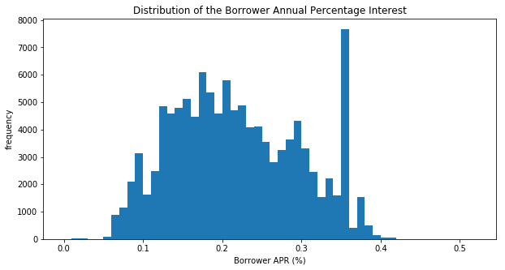

```python
# plotting a histogram covering the distribution of the BorrowerAPR
bins = np.arange(0, df_loan_copy['BorrowerAPR'].max()+0.01, 0.01)

plt.figure(figsize = [10, 5])
plt.title('Distribution of the Borrower Annual Percentage Interest')
plt.xlabel('Borrower APR (%)')
plt.ylabel('frequency')
plt.hist( data = df_loan_copy, x = 'BorrowerAPR', bins = bins );
```

## Distribution of LoanOriginalAmount

```python
# getting general statistics
df_loan_copy['LoanOriginalAmount'].describe()
```

```
count    113912.000000
mean       8338.015661
std        6245.940592
min        1000.000000
25%        4000.000000
50%        6500.000000
75%       12000.000000
max       35000.000000
Name: LoanOriginalAmount, dtype: float64
```

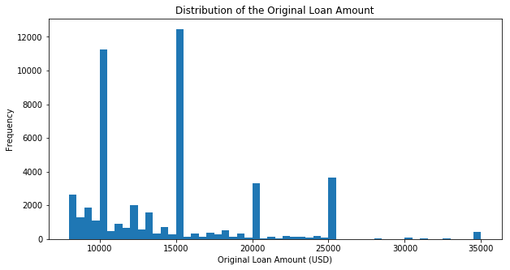

```python
# plotting a histogram covering the distribution of the LoanOriginalAmount
bins = np.arange(8000, df_loan_copy['LoanOriginalAmount'].max()+500, 500)
plt.figure(figsize = [10, 5]);
plt.title('Distribution of the Original Loan Amount')
plt.xlabel('Original Loan Amount (USD)')
plt.ylabel('Frequency')
plt.hist(data = df_loan_copy, x = 'LoanOriginalAmount', bins = bins );
```

## Employment status effect on an individual's eligiblity for a loan

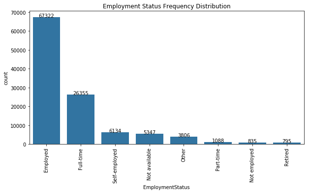

```python
# A count plot covering the distribution of the Employment status
base_color = sb.color_palette()[0]
type_order = df_loan_copy['EmploymentStatus'].value_counts().index

plt.figure(figsize=[10, 5])
plt.title('Employment Status Frequency Distribution')
plt.xlabel('Employment Status')
plt.ylabel('Frequency')

sb.countplot(data = df_loan_copy, x = 'EmploymentStatus', color = base_color, order = type_order);

locs, labels = plt.xticks(rotation=90)
job_counts = df_loan_copy['EmploymentStatus'].value_counts()

for loc, label in zip(locs, labels):
    count = job_counts[label.get_text()]
    pct_string = '{}'.format(count)
    plt.text(loc, count, pct_string, ha = 'center', color = 'black')
```

## Distribution of StatedMonthlyIncome

The distribution of Stated monthly income is skewed right, that means a large number of individuals have their stated monthly income less than 30 thousand US Dollars. As such individuals with the income greater than 30 thousand US Dollars can be considered to be a very small portion of the entire dataset ( outliers )

```python
# getting general statistics
df_loan_copy['StatedMonthlyIncome'].describe()
```

```
count    1.139120e+05
mean     5.606973e+03
std      7.478338e+03
min      0.000000e+00
25%      3.200000e+03
50%      4.666667e+03
75%      6.817083e+03
max      1.750003e+06
Name: StatedMonthlyIncome, dtype: float64
```

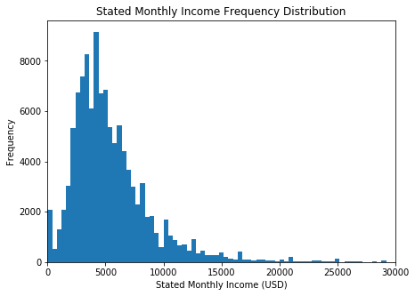

```python
bins = np.arange(0, 40000, 400)

plt.figure(figsize=[7, 5])
plt.xlim(1, 30000)
plt.title('Stated Monthly Income Frequency Distribution')
plt.xlabel('Stated Monthly Income (USD)')
plt.ylabel('Frequency')
plt.hist(data = df_loan_copy, x = 'StatedMonthlyIncome', bins = bins);
```

From the above plot shows the distribution of Stated monthly income is skewed right, that means a large number of individuals have their stated monthly income less than 30 thousand US Dollars. As such individuals with the income greater than 30 thousand US Dollars can be considered to be a very small portion of the entire dataset ( outliers )

```python
# removing outliers after limiting the axes to 30000 USD
df_loan_copy = df_loan_copy[df_loan_copy['StatedMonthlyIncome'] <= 30000]
```

```python
# check to see if there are any values > 30000
(df_loan_copy['StatedMonthlyIncome']>30000).sum()
```

```
0
```

### Is Income range part of the requirements to be eligible for a loan?

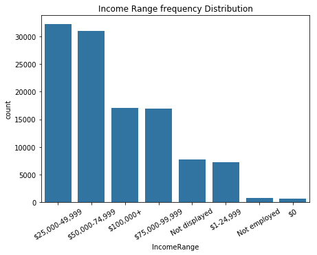

```python
# A count plot covering the distribution of the IncomeRange
base_color = sb.color_palette()[0]

plt.figure(figsize=[7, 5])
plt.title('Income Range frequency Distribution')
plt.xlabel('Income Range')
plt.ylabel('Frequency')
plt.xticks(rotation=30)
sb.countplot(data = df_loan_copy, x = 'IncomeRange', color = base_color);
```

The above plot shows that most individual who can get a loan from Prosper usually have an income range between 25 and 75 thousand US dollars but this plot does not actually show an relationship between income range and loan amount possibility.

## Distribution of ProsperRating (Alpha)

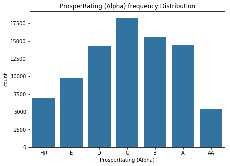

```python
# A count plot covering the distribution of the IncomeRange
base_color = sb.color_palette()[0]

plt.figure(figsize=[7, 5])
plt.title('ProsperRating (Alpha) frequency Distribution')
plt.xlabel('ProsperRating (Alpha)')
plt.ylabel('Count')
sb.countplot(data = df_loan_copy, x = 'ProsperRating (Alpha)', color = base_color);
```

From the above plot, we can see the distribution of the aplphabetical prosper rating is somewhat normal.

### What is the Loan status of individuals with Loan?

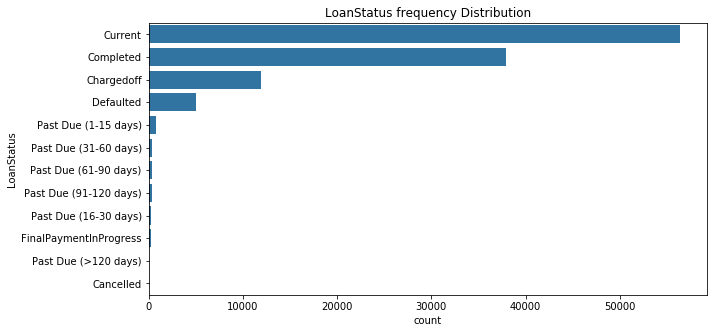

```python
# A count plot covering the distribution of the LoanStatus
base_color = sb.color_palette()[0]

type_order = df_loan_copy['LoanStatus'].value_counts().index
plt.figure(figsize=[10, 5])
plt.title('LoanStatus frequency Distribution');
sb.countplot(data = df_loan_copy, y = 'LoanStatus', order=type_order , color = base_color);
```

The above plot shows that more than 50,000 individuals have a current loan. Also, some individauls have completed the loan and the number of past due and cancelled loans are quite low.

### What are the top 15 occupations that apply for loans?

```python
# getting value_counts
df_loan_copy['Occupation'].value_counts().sort_values(ascending=False).head(15)
```

```
Other                       28569
Professional                13582
Computer Programmer          4476
Executive                    4231
Teacher                      3759
Administrative Assistant     3688
Analyst                      3595
Sales - Commission           3429
Accountant/CPA               3226
Clerical                     3164
Sales - Retail               2795
Skilled Labor                2746
Retail Management            2601
Nurse (RN)                   2486
Construction                 1785
Name: Occupation, dtype: int64
```

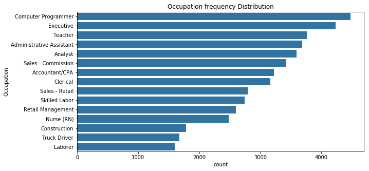

```python
# A count plot covering the top 10 occupation that borrow loans
base_color = sb.color_palette()[0]
type_order = df_loan_copy['Occupation'].value_counts(normalize=True).sort_values(ascending=False).head(17).index

type_order = type_order[2:]
plt.figure(figsize=[10, 5])
plt.title('Occupation frequency Distribution');
sb.countplot(data = df_loan_copy , y = 'Occupation', color = base_color , order = type_order);
```

In the above plot, I dropped the Other and Professional values because they are to generic and provided little to no information about an individual's occupation. Then I plotted the values such as computer programmer, executive and administrative assistant and others which are defined occupations.

### Discuss the distribution(s) of your variable(s) of interest. Were there any unusual points? Did you need to perform any transformations?

No transformations was needed for the BorrowerAPR. it appears to be a multimodal distribution with its lowest values starting from around 0.05 and ending at 0.4.

## Quantitative against Quantitative Features:

I will start with looking if there is a correlation between these two quantitative variables in our dataset through the use of a scatterplot and a heatmap

## BorrowerAPR vs. LoanOriginalAmont

Is a relationship between the Borrower's APR and Loan Original amount?

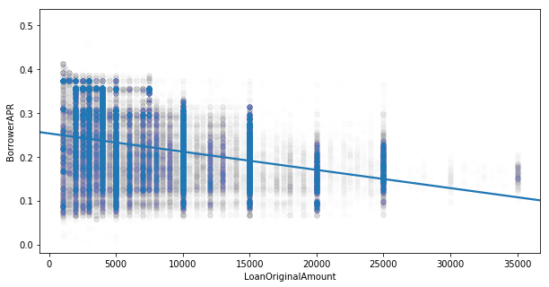

```python
# Scatter plot showing the correlation between two variables
plt.figure(figsize = [10, 5])

plt.xlabel('LoanOriginalAmount (USD)')
plt.ylabel('BorrowerAPR (%)')
sb.regplot(data = df_loan_copy, x = 'LoanOriginalAmount', y = 'BorrowerAPR', scatter_kws={'alpha': 1/180} );
```

```python
# checking the correlation between LoanoriginalAmount and BorrowerAPR and rounding to 3 d.p
round(df_loan_copy['LoanOriginalAmount'].corr(df_loan_copy['BorrowerAPR']), 3)
```

```
-0.32300000000000001
```

This plot and calculation above shows that the Borrower APR is negatively correlated with Loan original amount because at different size of the loan amount taken, the Borrower APR has a large range but the range of Borrower APR decreases with the increase in Loan original amount.

## BorrowerAPR vs. StatedMontlyIncome and LoanOriginalAmount

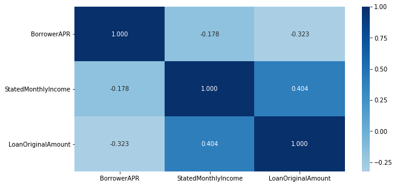

```python
# Scatter plot showing the correlation between three variables
data = df_loan_copy[['BorrowerAPR', 'StatedMonthlyIncome', 'LoanOriginalAmount']]
plt.figure(figsize = [10, 5])
sb.heatmap(data.corr(), annot = True, fmt = '.3f', cmap = 'Blues', center = 0);
```

Again with the above heatmap, we can see that the plot depicts that the correlation coefficient of BorrowerAPR and Loan original amount is -0.323 as the scatterplot clearly shows in the previous scatter plot meaning these two variables are negatively correlated. Also, taking a look at the relationship between the Loan original amount and Stated monthly income, we can see that they are positively correlated with a correlation coefficient of 0.404. Thus, we can extrapolate that borrowers with a high monthly income could loan more money because their BorrowerAPR will be lower compared to those with lower monthly income.

## Quantitative against Qualitative Features:

I will start with looking if there is a realtionship between quantitive and qualitative variables in our dataset through the use of a violin and box plots

## Occupation vs. BorrowerRate

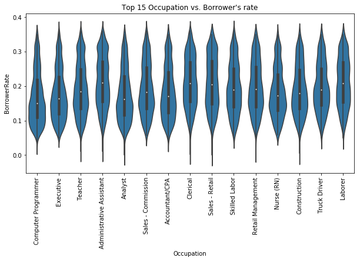

```python
# voilin plot showing the distribution between the two variables
plt.figure(figsize=[10, 5])

type_order = df_loan_copy['Occupation'].value_counts(normalize=True).sort_values(ascending=False).head(17).index
type_order = type_order[2:]

plt.title("Top 15 Occupation vs. Borrower's rate");
plt.xticks(rotation=90);
sb.violinplot(data = df_loan_copy, x = 'Occupation' , y =  'BorrowerRate', color = base_color, order = type_order);
```

The plot above shows that occupation actually affects the borrower rate that low income occupation mostly have a higher median rate.

## IncomeRange vs. BorrowerAPR

Is Income range a factor in the Borrower APR?

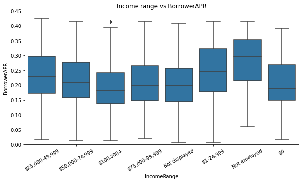

```python
plt.figure(figsize=[10, 5])
plt.title("Income range vs BorrowerAPR")
plt.xticks(rotation=30);
plt.ylim(0,0.45);
sb.boxplot(data = df_loan_copy, x = 'IncomeRange', y = 'BorrowerAPR', color = base_color);
```

## Qualitative against Qualitative Features:

I will start with looking if there is a realtionship between these two quanlitative variables in our dataset through the use of a clustered bar charts

## EmploymentStatus vs. ProsperRating Alpha

Is there is a relationship between Employment ststus and their Prosper rating for a loan?

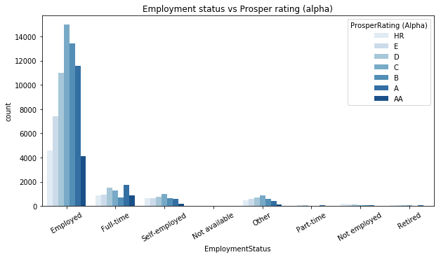

```python
plt.figure(figsize = [10,5])
plt.title('Employment status vs Prosper rating (alpha)')
plt.xticks(rotation=30)
sb.countplot(data = df_loan_copy, x = 'EmploymentStatus', hue = 'ProsperRating (Alpha)', palette = 'Blues');
```

The above chart is not sufficient to show any relationship between Employment status and prosper rating because the Employment status variable do not have enough data some of its categories to show a direct correlation between it and Prosper rating

## ProsperRating (Alpha) vs. Term

Is there is a relationship between Prosper rating and Term of a loan?

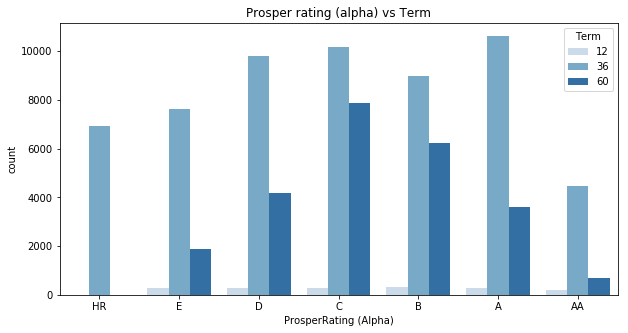

```python
plt.figure(figsize = [10,5])
plt.title('Prosper rating (alpha) vs Term')
sb.countplot(data = df_loan_copy, x = 'ProsperRating (Alpha)', hue = 'Term', palette = 'Blues');
```

### Talk about some of the relationships you observed in this part of the investigation. How did the feature(s) of interest vary with other features in the dataset?

I discovered that the Borrower APR has a negative correlation with the Loan original amount which means the higher the loan original amount, the lower the Borrower APR while Loan original amount has a positive correlation with an individual's stated monthly income.

## Multivariate Exploration

I want to explore the relationship between the Prosper rating and term) across the BorrowerAPR and Loan original amount variable.

## Relationship between Borrower APR and Loan original amount across Prosper rating

Interestingly, the relationship between borrower APR and loan amount turns from negative to slightly positive when the Prosper ratings are increased from HR to A or better. This may because people with A or AA ratings tend to borrow more money, increasting APR could prevent them borrow even more and maximize the profit. But people with lower ratings tend to borrow less money, decreasing APR could encourage them to borrow more.

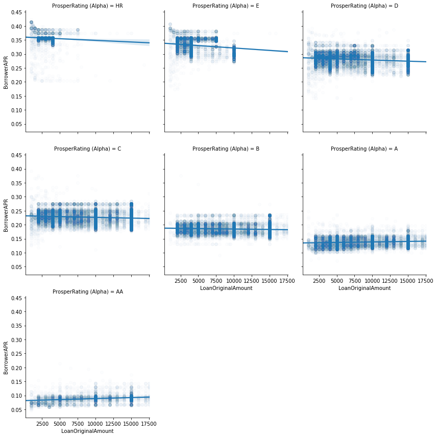

```python
# plotting
g = sb.FacetGrid(data = df_loan_copy, col='ProsperRating (Alpha)', col_wrap = 3, size = 4, margin_titles = True)
g.map(sb.regplot, 'LoanOriginalAmount', 'BorrowerAPR', x_jitter=0.05, scatter_kws={'alpha':1/100});
```

## Relationship between Borrower APR and Prosper rating across Loan Term

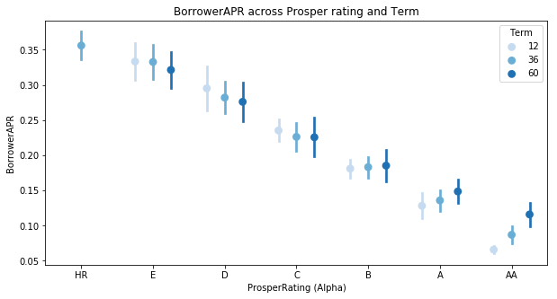

```python
# plotting
plt.figure(figsize = [10,5])
plt.title('BorrowerAPR across Prosper rating and Term')
sb.pointplot(data = df_loan_copy, x = 'ProsperRating (Alpha)', y = 'BorrowerAPR', hue = 'Term', palette = 'Blues' , linestyles = '', ci = 'sd', dodge = 0.5);
```

### Term across BorrowerAPR and Loan original amount

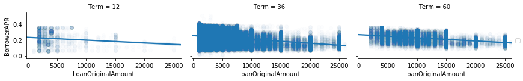

```python
# plotting
g=sb.FacetGrid(data = df_loan_copy, aspect = 2, col = 'Term', col_wrap = 3, size = 2)
g.map(sb.regplot, 'LoanOriginalAmount', 'BorrowerAPR', x_jitter = 0.02, scatter_kws={'alpha':1/80});
g.add_legend();
```

### Were there any interesting or surprising interactions between features?

I noticed that the BorrowerAPR and Loan original amount turned out to be negatively correlated with Prosper ratings when it is in the range of HR to B, but the correlation is turned out to be positive when the Prosper ratings are A and AA. Also, a decrease in BorrowerAPR correlated with an increase in the term for loan in the range of HR and C Prosper ratings while those with B and AA ratings, there is a direct increase in BorrowerAPR as term increases.